# Project 1 Chess Tournament

Jill Anderson

Due: September 24, 2017

## INTRODUCTION

##### Read in the raw data of a chess tournament.

##### Create a table comprised of the following attributes: Player’s Name, Player’s State, Total Points, Player’s Pre-Rating, and Average Pre-Rating Rating of Opponents.

##### Desired output: For the first player, the information would be: Gary Hua, ON, 6.0, 1794, 1605.

### Load libraries.

```r
library(stringr)
library(DT)
```

### Load raw data file into R Studio.

```r
tournamentraw <- readLines("~/Desktop/tournamentinfo.txt")
```

## DATA DESCRIPTION

#### Evaluate and describe the raw data format to determine what steps will be required to work with the desired attributes.

```r
head(tournamentraw)
```

```
## [1] "-----------------------------------------------------------------------------------------"
## [2] " Pair | Player Name                     |Total|Round|Round|Round|Round|Round|Round|Round| "
## [3] " Num  | USCF ID / Rtg (Pre->Post)       | Pts |  1  |  2  |  3  |  4  |  5  |  6  |  7  | "
## [4] "-----------------------------------------------------------------------------------------"
## [5] "    1 | GARY HUA                        |6.0  |W  39|W  21|W  18|W  14|W   7|D  12|D   4|"
## [6] "   ON | 15445895 / R: 1794   ->1817     |N:2  |W    |B    |W    |B    |W    |B    |W    |"
```

```r
tail(tournamentraw)
```

```
## [1] "   63 | THOMAS JOSEPH HOSMER            |1.0  |L   2|L  48|D  49|L  43|L  45|H    |U    |"
## [2] "   MI | 15057092 / R: 1175   ->1125     |     |W    |B    |W    |B    |B    |     |     |"
## [3] "-----------------------------------------------------------------------------------------"
## [4] "   64 | BEN LI                          |1.0  |L  22|D  30|L  31|D  49|L  46|L  42|L  54|"
## [5] "   MI | 15006561 / R: 1163   ->1112     |     |B    |W    |W    |B    |W    |B    |B    |"
## [6] "-----------------------------------------------------------------------------------------"
```

```r
NROW(tournamentraw)
```

```
## [1] 196
```

```r
NCOL(tournamentraw)
```

```
## [1] 1
```

### Data descripion based on raw data

##### Header: described in two rows.

##### Columns: information is separated by | but the table is only one row.

##### Rows: separated between entries with a series of hyphens.

##### Each entry: described in two rows

###### the first row includes the player’s Name, Total Points, Results of each Round;

###### the second row includes the player’s USCF ID, rating before and after the tournament.

##### There are 64 players.

## DATA PROCESSING

### Tidy and process the data in R to make it more usable.

Primary objective, bring all of the data for each player into one row and extract the requested attributes.

#### Determine the the total rows in the dataset.

```r
tournamentrows <- length(tournamentraw)
tournamentrows
```

```
## [1] 196
```

#### Create a new table with just the rows that start with the Player Names.

Start with the fifth row to account for the header and hyphens

```r
PlayerNameRows <- tournamentraw[seq(5, tournamentrows, 3)]
head(PlayerNameRows)
```

```
## [1] "    1 | GARY HUA                        |6.0  |W  39|W  21|W  18|W  14|W   7|D  12|D   4|"
## [2] "    2 | DAKSHESH DARURI                 |6.0  |W  63|W  58|L   4|W  17|W  16|W  20|W   7|"
## [3] "    3 | ADITYA BAJAJ                    |6.0  |L   8|W  61|W  25|W  21|W  11|W  13|W  12|"
## [4] "    4 | PATRICK H SCHILLING             |5.5  |W  23|D  28|W   2|W  26|D   5|W  19|D   1|"
## [5] "    5 | HANSHI ZUO                      |5.5  |W  45|W  37|D  12|D  13|D   4|W  14|W  17|"
## [6] "    6 | HANSEN SONG                     |5.0  |W  34|D  29|L  11|W  35|D  10|W  27|W  21|"
```

#### Create a new table with just the rows that start with the Player State.

Start with the sixth row

```r
PlayerStateRows <- tournamentraw[seq(6, tournamentrows, 3)]
head(PlayerStateRows)
```

```
## [1] "   ON | 15445895 / R: 1794   ->1817     |N:2  |W    |B    |W    |B    |W    |B    |W    |"
## [2] "   MI | 14598900 / R: 1553   ->1663     |N:2  |B    |W    |B    |W    |B    |W    |B    |"
## [3] "   MI | 14959604 / R: 1384   ->1640     |N:2  |W    |B    |W    |B    |W    |B    |W    |"
## [4] "   MI | 12616049 / R: 1716   ->1744     |N:2  |W    |B    |W    |B    |W    |B    |B    |"
## [5] "   MI | 14601533 / R: 1655   ->1690     |N:2  |B    |W    |B    |W    |B    |W    |B    |"
## [6] "   OH | 15055204 / R: 1686   ->1687     |N:3  |W    |B    |W    |B    |B    |W    |B    |"
```

### Player Name

From PlayerNameRows, extract the Player’s Name

```r
PlayerName <- str_trim(str_extract(PlayerNameRows, "(\\w+\\s){2,3}"))
head(PlayerName)
```

```
## [1] "GARY HUA"            "DAKSHESH DARURI"     "ADITYA BAJAJ"
## [4] "PATRICK H SCHILLING" "HANSHI ZUO"          "HANSEN SONG"
```

### Player State

From PlayerStateRows, extract the Player State taking the first two letters in the string.

```r
PlayerState <- str_extract(PlayerStateRows, "\\w+")
head(PlayerState)
```

```
## [1] "ON" "MI" "MI" "MI" "MI" "OH"
```

### Total Points

From the PlayerNameRows, extract the Total Points.

```r
TotalPoints <- as.numeric(str_extract(PlayerNameRows, "\\d+\\.\\d+"))
head(TotalPoints)
```

```
## [1] 6.0 6.0 6.0 5.5 5.5 5.0
```

### Player Pre-Rating

From the PlayerStateRows, extract the Player’s Pre-Rating by first taking the string and then pulling out the number to remove the spaces.

```r
PlayerPreRating <- str_extract(PlayerStateRows, "[^\\d]\\d{3,4}[^\\d]")
PlayerPreRating <- as.integer(str_extract(PlayerPreRating, "\\d+"))
head(PlayerPreRating)
```

```
## [1] 1794 1553 1384 1716 1655 1686
```

### Calculate the average of the Opponents’ Pre-Ratings for each player

#### Find Opponents

```r
FindOpponents <- str_extract_all(PlayerNameRows, "\\d+\\|")
FindOpponents <- str_extract_all(FindOpponents, "\\d+")
head(FindOpponents)
```

```
## [[1]]
## [1] "39" "21" "18" "14" "7"  "12" "4"
##
## [[2]]
## [1] "63" "58" "4"  "17" "16" "20" "7"
##
## [[3]]
## [1] "8"  "61" "25" "21" "11" "13" "12"
##
## [[4]]
## [1] "23" "28" "2"  "26" "5"  "19" "1"
##
## [[5]]
## [1] "45" "37" "12" "13" "4"  "14" "17"
##
## [[6]]
## [1] "34" "29" "11" "35" "10" "27" "21"
```

#### Pair Numbers

From the PlayerNameRows, extract the pair numbers for use in the opponent pre-rating calculation.

```r
Pair <- as.integer(str_extract(PlayerNameRows, "\\d+"))
head(Pair)
```

```
## [1] 1 2 3 4 5 6
```

#### Calculate Opponents’ Average Pre-Rating

Run a loop to calculate the mean rating of the opponents of each player using the Pair numbers for all rows.

```r
AveOpponentRating <- Pair
for (i in 1:NROW(Pair)) {
  AveOpponentRating[i] <- mean(PlayerPreRating[as.numeric(unlist(FindOpponents[Pair[i]]))])
}
head(AveOpponentRating)
```

```
## [1] 1605.286 1469.286 1563.571 1573.571 1500.857 1518.714
```

#### Round up the calculated average ratings to the nearest whole integer

```r
AveOpponentRating <- round(AveOpponentRating)
head(AveOpponentRating)
```

```
## [1] 1605 1469 1564 1574 1501 1519
```

## COMBINE PROCESSED DATA

Put together all of the extracted data into a final set.

#### Create a new dataframe with the extracted desired data attributes

```r
FinalData <- data.frame(PlayerName, PlayerState, TotalPoints, PlayerPreRating, AveOpponentRating)
head(FinalData)
```

```
##            PlayerName PlayerState TotalPoints PlayerPreRating
## 1            GARY HUA          ON         6.0            1794
## 2     DAKSHESH DARURI          MI         6.0            1553
## 3        ADITYA BAJAJ          MI         6.0            1384
## 4 PATRICK H SCHILLING          MI         5.5            1716
## 5          HANSHI ZUO          MI         5.5            1655
## 6         HANSEN SONG          OH         5.0            1686
##   AveOpponentRating
## 1              1605
## 2              1469
## 3              1564
## 4              1574
## 5              1501
## 6              1519
```

#### Rename the columns to improve formating

```r
colnames(FinalData) <- c("Player's Name", "Player's State", "Total Number of Points", "Player's Pre-Rating", "Average Rating of Opponents")
head(FinalData)
```

```
##         Player's Name Player's State Total Number of Points
## 1            GARY HUA             ON                    6.0
## 2     DAKSHESH DARURI             MI                    6.0
## 3        ADITYA BAJAJ             MI                    6.0
## 4 PATRICK H SCHILLING             MI                    5.5
## 5          HANSHI ZUO             MI                    5.5
## 6         HANSEN SONG             OH                    5.0
##   Player's Pre-Rating Average Rating of Opponents
## 1                1794                        1605
## 2                1553                        1469
## 3                1384                        1564
## 4                1716                        1574
## 5                1655                        1501
## 6                1686                        1519
```

## EXPORT DATA

Export final data to a new CSV file.

```r
write.csv(FinalData,file="Chess Data Extracted Jill Anderson.csv")
```

## REFORMAT TABLE

Improve the data table for display.

```r
datatable(FinalData)
```

|  | Player's Name | Player's State | Total Number of Points | Player's Pre-Rating | Average Rating of Opponents |
| --- | --- | --- | --- | --- | --- |
| 1 | GARY HUA | ON | 6 | 1794 | 1605 |
| 2 | DAKSHESH DARURI | MI | 6 | 1553 | 1469 |
| 3 | ADITYA BAJAJ | MI | 6 | 1384 | 1564 |
| 4 | PATRICK H SCHILLING | MI | 5.5 | 1716 | 1574 |
| 5 | HANSHI ZUO | MI | 5.5 | 1655 | 1501 |
| 6 | HANSEN SONG | OH | 5 | 1686 | 1519 |
| 7 | GARY DEE SWATHELL | MI | 5 | 1649 | 1372 |
| 8 | EZEKIEL HOUGHTON | MI | 5 | 1641 | 1468 |
| 9 | STEFANO LEE | ON | 5 | 1411 | 1523 |
| 10 | ANVIT RAO | MI | 5 | 1365 | 1554 |

[output cut: 54 more lines]

## ANALYZE DATA

#### Basic data analytics

Comparing the individual Players’ Pre-Ratings to the Average Opponents’ Pre-Ratings, one would expect the means to be identical and the medians to be similar. The min and max from the individual Players’ Pre-Ratings should be lower and higher respectively compared to the Average Opponents’ Pre-Ratings to demonstrate an average distribution of opponent pre-ratings across all players.

##### Statistical spread of Player’s Pre-Rating

```r
summary(FinalData$`Player's Pre-Rating`)
```

```
##    Min. 1st Qu.  Median    Mean 3rd Qu.    Max.
##     377    1227    1407    1378    1583    1794
```

##### Statistical spread of Average Opponents’ Pre-Rating

```r
summary(FinalData$`Average Rating of Opponents`)
```

```
##    Min. 1st Qu.  Median    Mean 3rd Qu.    Max.
##    1107    1310    1382    1379    1481    1605
```

## VISUALIZE DATA

#### Create a historgram of the Player Pre-Ratings

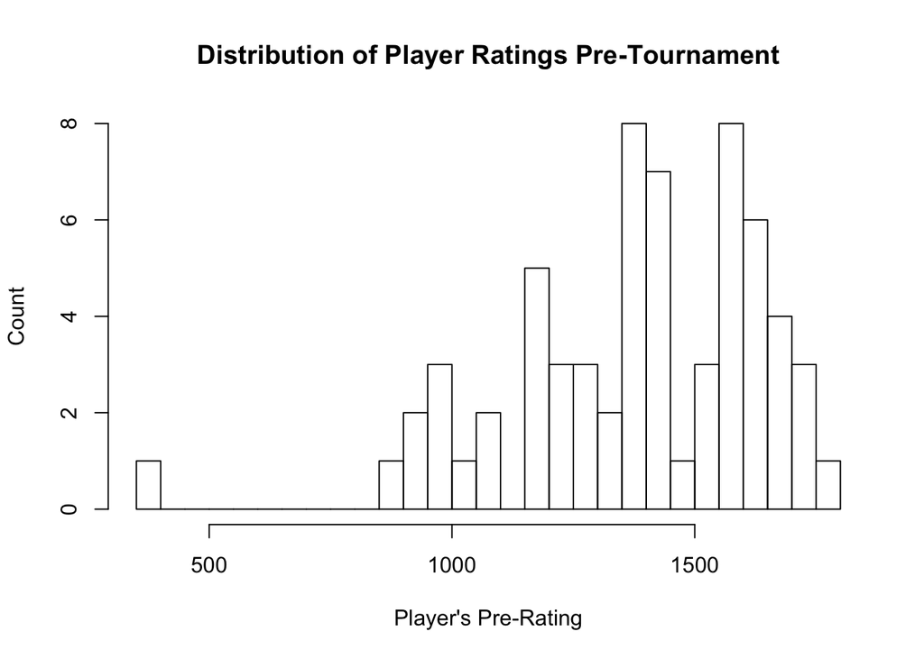

```r
hist(FinalData$`Player's Pre-Rating`, breaks = 30, main = "Distribution of Player Ratings Pre-Tournament", xlab = "Player's Pre-Rating", ylab = "Count")
```

#### Create a historgram of the Total Points per Player

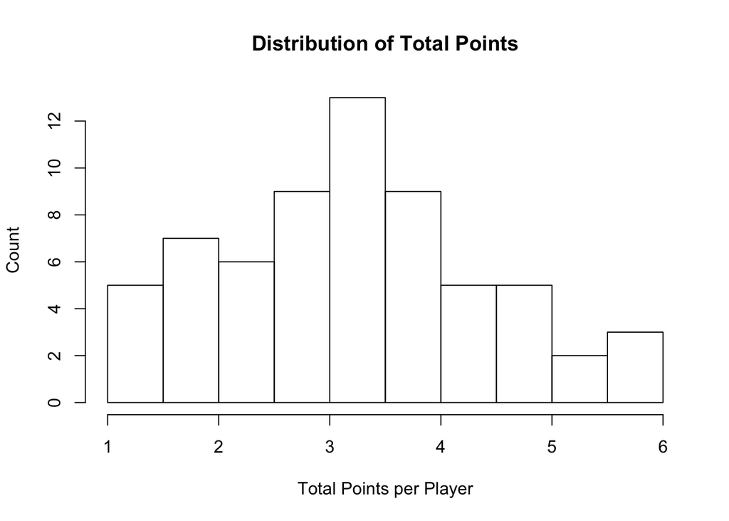

```r
hist(FinalData$`Total Number of Points`, breaks = 10, main = "Distribution of Total Points", xlab = "Total Points per Player", ylab = "Count")
```

#### Compare players from each state in the following columns: “Player State”, “Average Total Number of Points”, “Average Player’s Pre-Rating”, “Average Rating of Opponents”

#### PlayerState = MI

```r
FinalDataMI = subset(FinalData, PlayerState == "MI")
FinalDataMI_Num = round(NROW(FinalDataMI))
FinalDataMI_MeanPoints = round(mean(FinalDataMI$`Total Number of Points`))
FinalDataMI_PlayerPreRating = round(mean(FinalDataMI$`Player's Pre-Rating`))
FinalDataMI_AveOpponent = round(mean(FinalDataMI$`Average Rating of Opponents`))
FinalDataMISum <- data.frame("MI", FinalDataMI_Num, FinalDataMI_MeanPoints, FinalDataMI_PlayerPreRating, FinalDataMI_AveOpponent)
colnames(FinalDataMISum) <- c("State", "Number of Players", "Average Total Number of Points", "Average Player Pre-Rating", "Average Rating of Opponents")
FinalDataMISum
```

```
##   State Number of Players Average Total Number of Points
## 1    MI                55                              3
##   Average Player Pre-Rating Average Rating of Opponents
## 1                      1362                        1374
```

#### PlayerState = ON

```r
FinalDataON = subset(FinalData, PlayerState == "ON")
FinalDataON_Num = round(NROW(FinalDataON))
FinalDataON_MeanPoints = round(mean(FinalDataON$`Total Number of Points`))
FinalDataON_PlayerPreRating = round(mean(FinalDataON$`Player's Pre-Rating`))
FinalDataON_AveOpponent = round(mean(FinalDataON$`Average Rating of Opponents`))
FinalDataONSum <- data.frame("ON", FinalDataON_Num, FinalDataON_MeanPoints, FinalDataON_PlayerPreRating, FinalDataON_AveOpponent)
colnames(FinalDataONSum) <- c("State", "Number of Players", "Average Total Number of Points", "Average Player Pre-Rating", "Average Rating of Opponents")
FinalDataONSum
```

```
##   State Number of Players Average Total Number of Points
## 1    ON                 8                              4
##   Average Player Pre-Rating Average Rating of Opponents
## 1                      1454                        1396
```

#### PlayerState = OH

```r
FinalDataOH = subset(FinalData, PlayerState == "OH")
FinalDataOH_Num = round(NROW(FinalDataOH))
FinalDataOH_MeanPoints = round(mean(FinalDataOH$`Total Number of Points`))
FinalDataOH_PlayerPreRating = round(mean(FinalDataOH$`Player's Pre-Rating`))
FinalDataOH_AveOpponent = round(mean(FinalDataOH$`Average Rating of Opponents`))
FinalDataOHSum <- data.frame("OH", FinalDataOH_Num, FinalDataOH_MeanPoints, FinalDataOH_PlayerPreRating, FinalDataOH_AveOpponent)
colnames(FinalDataOHSum) <- c("State", "Number of Players", "Average Total Number of Points", "Average Player Pre-Rating", "Average Rating of Opponents")
FinalDataOHSum
```

```
##   State Number of Players Average Total Number of Points
## 1    OH                 1                              5
##   Average Player Pre-Rating Average Rating of Opponents
## 1                      1686                        1519
```

#### Combine all summary data by state into one table to compare

This comparison shows MI had the most representation with 55 players and OH had the least with 1. The one player from OH had a higher rating than the average ratings of the players from MI and ON and also played opponents with a higher average rating than the averages played in the MI and ON, though looking at a distribution of one player is not enough to draw conclusions. Instead comparing MI and ON, the table shows ON has a higher average player pre-rating.

```r
FinalDataSum <- rbind(FinalDataMISum, FinalDataONSum, FinalDataOHSum)
datatable(FinalDataSum)
```

|  | State | Number of Players | Average Total Number of Points | Average Player Pre-Rating | Average Rating of Opponents |
| --- | --- | --- | --- | --- | --- |
| 1 | MI | 55 | 3 | 1362 | 1374 |
| 2 | ON | 8 | 4 | 1454 | 1396 |
| 3 | OH | 1 | 5 | 1686 | 1519 |